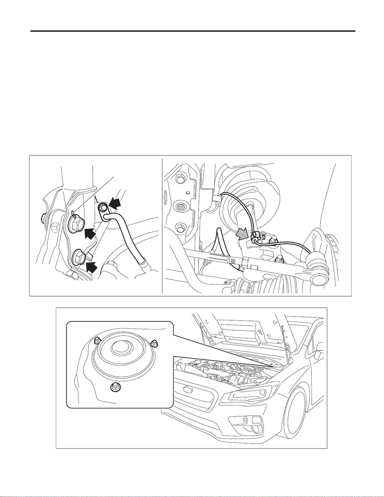

FS-44

Front Strut

FRONT SUSPENSION

8. Front Strut

A: REMOVAL

1) Disconnect the ground cable from battery. <Ref. to NT-5, BATTERY, NOTE, Note.>

NOTE:

For models other than STI model, disconnect the ground terminal from battery sensor.

2) Lift up the vehicle, and then remove the front wheels.

3) Remove the strut assembly.

(1) Place an alignment mark (a) on the adjusting bolt and the strut.

(2) Remove the brake hose bracket.

(3) Remove the clamp of ABS wheel speed sensor harness.

(4) Remove the adjusting bolts and flange bolts for the strut assembly.

CAUTION:

While holding the adjusting bolt side, tighten the nut side.

(5) Remove the three nuts securing strut mount to body.

FS-00661

(a)

FS-00662

FS-45

Front Strut

FRONT SUSPENSION

B: INSTALLATION

CAUTION:

For parts which are not reusable, always use new parts.

1) Install the strut mount - front at the upper side of the strut to the vehicle body.

Tightening torque:

20 N·m (2.0 kgf-m, 14.8 ft-lb)

NOTE:

While holding the bolt head of adjusting bolt, tighten the nut.

Tightening torque:

155 N·m (15.8 kgf-m, 114.3 ft-lb)

3) Secure the ABS wheel speed sensor harness bracket to the strut.

CAUTION:

During the installation, make sure that the marking of ABS wheel speed sensor harness does not

twist.

4) Install the brake hose bracket.

Tightening torque:

33 N·m (3.4 kgf-m, 24.3 ft-lb)

5) Install the front wheels.

Tightening torque:

120 N·m (12.2 kgf-m, 88.5 ft-lb)

6) Connect the battery ground terminal. <Ref. to NT-5, BATTERY, NOTE, Note.>

NOTE:

For models other than STI model, connect the ground terminal to battery sensor.

7) Inspect the wheel alignment and adjust if necessary.

• Inspection: <Ref. to FS-10, INSPECTION, Wheel Alignment.>

• Adjustment: <Ref. to FS-15, ADJUSTMENT, Wheel Alignment.>

CAUTION:

When the wheel alignment has been adjusted, perform “VDC sensor midpoint setting mode” of the

VDC. <Ref. to VDC-16, ADJUSTMENT, VDC Control Module and Hydraulic Control Unit (VDCCM&H/U).>

8) Perform reinitialization of the auto headlight beam leveler system. (Model with auto headlight beam level-

er) <Ref. to LI-16, PROCEDURE, Auto Headlight Beam Leveler System.>

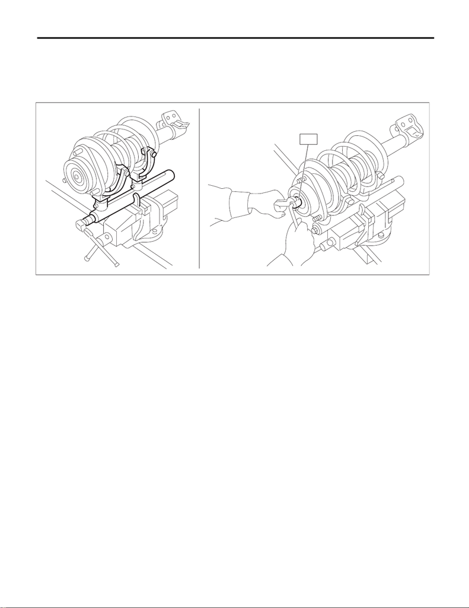

FS-46

Front Strut

FRONT SUSPENSION

C: DISASSEMBLY

1) Using a coil spring compressor, compress the coil spring.

2) Using a hexagon wrench to prevent strut rod from turning, remove the self-locking nut with ST.

Preparation tool:

ST: STRUT MOUNT SOCKET (20399AG000)

3) Remove the strut mount - front, spacer - front strut, dust cover - front strut and spring seat - front strut UPR

from the strut COMPL.

4) Gradually decrease the compression force of compressor, and remove the coil spring.

5) Remove the dust cover - inner and the helper - front strut.

FS-00408

ST

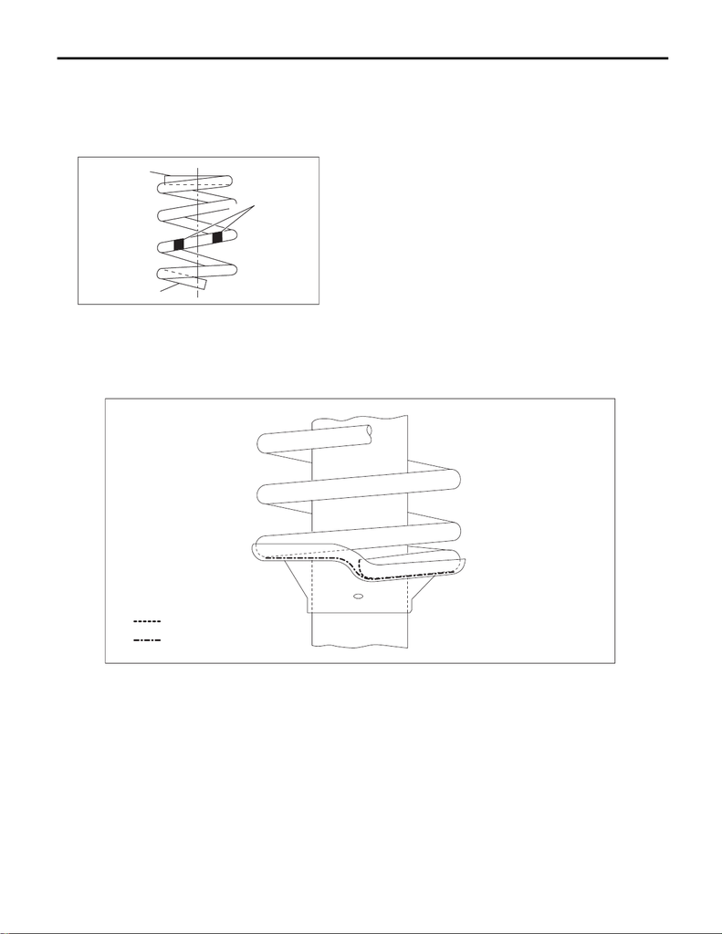

FS-47

Front Strut

FRONT SUSPENSION

D: ASSEMBLY

1) Before assembly, check each part. <Ref. to FS-49, INSPECTION, Front Strut.>

2) Using a coil spring compressor, compress the coil spring.

NOTE:

Make sure that the vertical install direction of the coil spring is as shown in the figure.

3) Set the coil spring correctly so that its end face (a) contacts the vertical surface (b) of the spring seat - front

strut LWR as shown in the figure.

4) Install the dust cover - inner and the helper - front strut to the piston rod.

(1) Diameter is small (upper part)

(2) Identification paint

(3) Diameter is large (bottom part)

FS-00675

(2)

(1)

(3)

FS-00536

:(b)

:(a)

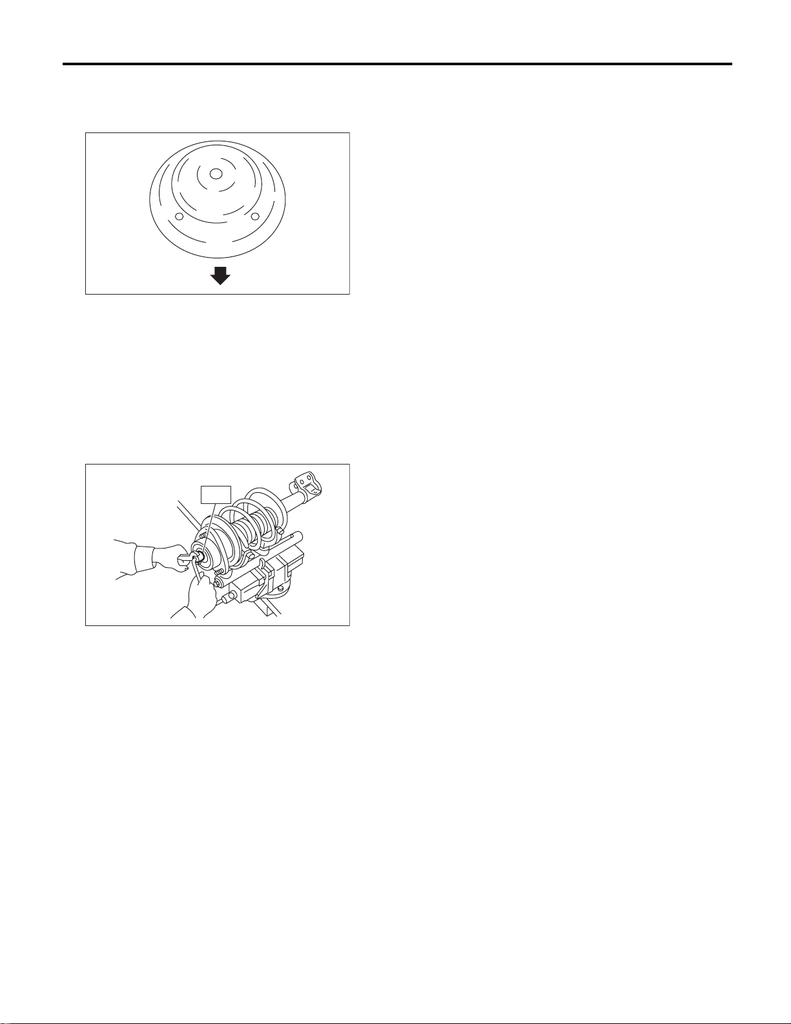

FS-48

Front Strut

FRONT SUSPENSION

5) Pull the piston rod fully upward, and install the spring seat and the dust cover - front strut.

NOTE:

Position the spring seat - front strut UPR as shown in the figure.

6) Install the spacer - front strut and the strut mount - front to the piston rod, and temporarily tighten a new

self-locking nut.

7) Using a hexagon wrench to prevent strut rod from turning, tighten the new self-locking nut with ST.

CAUTION:

Make sure that the strut mount - front turns smoothly after tightening.

Preparation tool:

ST: STRUT MOUNT SOCKET (20399AG000)

Tightening torque:

55 N·m (5.6 kgf-m, 40.6 ft-lb)

8) Loosen the coil spring compressor carefully.

FS-00128

(1)

(1) Outside of body

FS-00041

ST

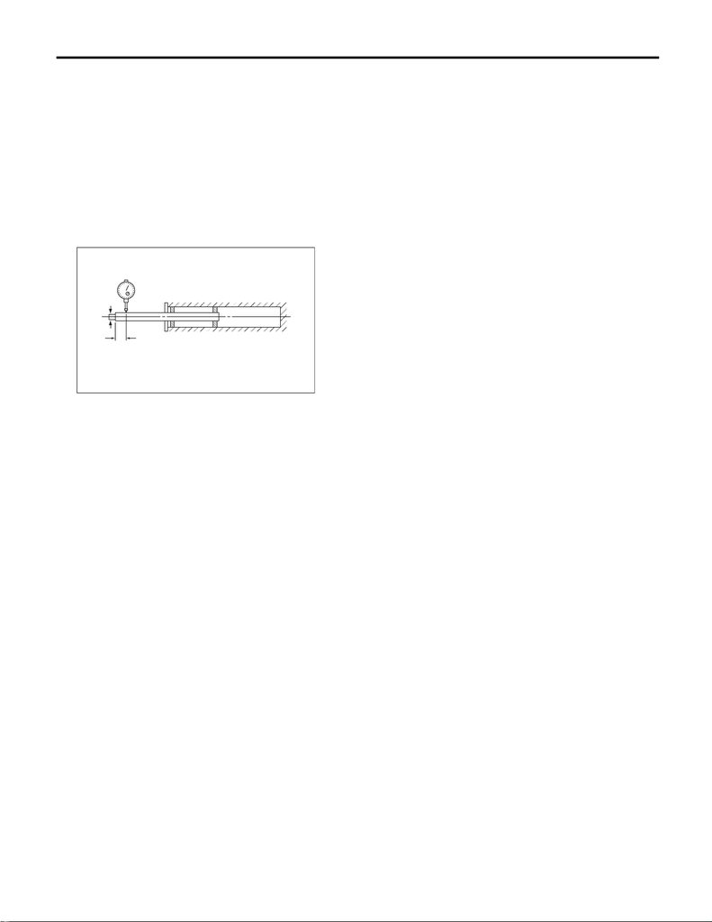

FS-49

Front Strut

FRONT SUSPENSION

E: INSPECTION

Check the removed part for wear, damage and cracks, and then repair or replace it if defective.

1. STRUT

1) Check for oil leaks.

2) Move the piston rod up and down to check that it operates smoothly without any hitch.

3) Check the piston rod for play.

(1) Fix the outer shell in place and fully extend the rod.

(2) Set the dial gauge on the end of the rod L [10 mm (0.39 in)].

(4) Apply a force of 20 N (2 kgf, 4 lbf) from the opposite direction of “W”, and then read the dial gauge in-

dication P

4) Replace the strut if faulty is found in the inspection or limit value is exceeded.

2. STRUT MOUNT - FRONT

Check the rubber part for deformation, cracks or deterioration, and then replace it with a new part if defective.

3. DUST COVER - INNER

If cracks or damage are found, replace it with a new part.

4. COIL SPRING - FRONT

If cracks, damage or deformation are found, replace it with a new part.

5. HELPER - FRONT STRUT

If major cracks or damage are found, replace it with a new part.

6. DUST COVER - FRONT

If major cracks or damage are found, replace it with a new part.

FS-00046

W

L

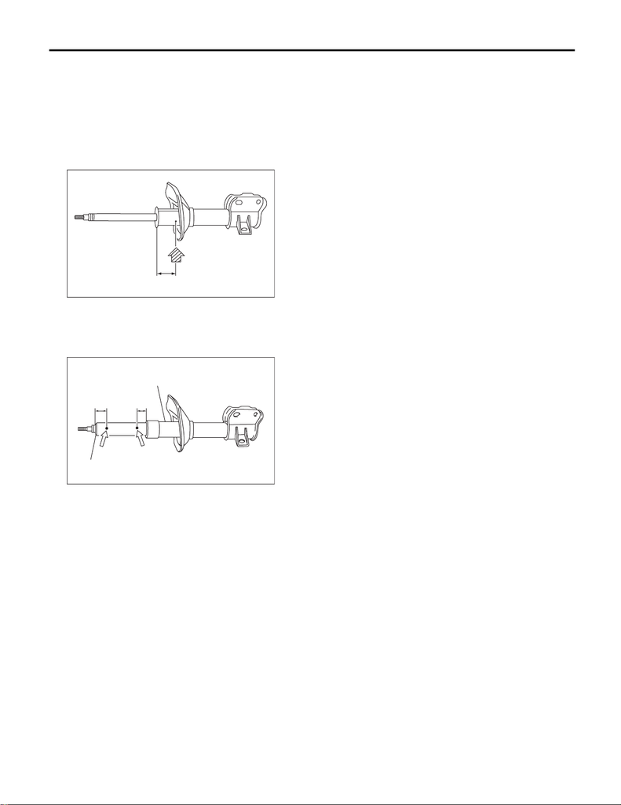

FS-50

Front Strut

FRONT SUSPENSION

F: DISPOSAL

CAUTION:

• Before handling struts, be sure to wear goggles to protect eyes from gas, oil and cutting powder.

• Do not disassemble the strut damper or throw into flames.

• When discarding gas filled struts, drill holes in them to purge the gas.

1) Place the strut on a level surface with the piston rod fully expanded.

2) Using a 2 — 3 mm (0.08 — 0.12 in) dia. drill, make holes in areas shown in the figure. (standard damper

model)

3) Using a 2 — 3 mm (0.08 — 0.12 in) dia. drill, make a hole into the position (1) first, and then (2). (inverted

damper model)

FS-00047

(1)

(1) 40 mm (1.57 in)

FS-00096

(1)

(4)

(2)

(3)

(1) 20 mm (0.78 in)

(2) 10 mm (0.39 in)

(3) Strut

(4) Damping tube